# Meta-repository for Turner et al., 2021

**Water storage and release policies for all large reservoirs of conterminous United States**

Sean Turner<sup>1*</sup>, Jennie Steyaert <sup>2</sup>, Laura Condon <sup>2</sup>, and Nathalie Voisin <sup>1,3</sup>

<sup>1</sup> Pacific Northwest National Laboratory <sup>2</sup> University of Arizona <sup>3</sup> University of Washington

* corresponding author: sean.turner@pnnl.gov

**Journal Article:** Turner, S.W., Steyaert, J.C., Condon, L. and Voisin, N., 2021. Water storage and release policies for all large reservoirs of conterminous United States. *Journal of Hydrology*, 603, p.126843.

**Reservoir Operating Policies Dataset:** `ISTARF-CONUS`:

[figure not shown]

### Contributing software

| Model | Version | Repository | DOI |
| --- | --- | --- | --- |
| `starfit` | 0.1.0 | https://github.com/IMMM-SFA/starfit/ |  |

### Data requirements

| Dataset | Version | Link | Supporting article to cite |
| --- | --- | --- | --- |
| Global Reservoir and Dam Database `GRanD` | 1.3 | http://globaldamwatch.org/grand/ | Lehner et al., 2011. *Frontiers in Ecology and the Environment* |
| Reservoir Operations for CONUS `ResOpsUS` | 1.0 |  | Steyaert et al., 2022, *Nature Scientific Data* |

### Example for inferring a reservoir policy using `starfit`

In Turner et al., 2021, reservoir operations data from `ResOpsUS` are used to infer the operating policies of different reservoirs. The policy inference code is contained in the `starfit` package.

For this example, you will need to first load some libraries:

```r
library(dplyr)
library(ggplot2)
library(starfit)
# note: you can install `starfit` using devtools:
# devtools::install_github("IMMM-SFA/starfit")
```

**NOTE: `ResOpsUS` is currently under embargo but will be publically available after November 8, 2021. Once these data are open, the `starfit` function `read_reservoir_data()` will allow one to access the data directly using `starfit` function `read_reservoir_data()`.

```r
read_reservoir_data(
  "https://raw.githubusercontent.com/IMMM-SFA/starfit/master/inst/extdata/",
  # ^^ a placeholder example record is stored at this site pending ResOpsUS public release
  297) ->
  Libby_res_data

Libby_res_data
```

```
## # A tibble: 16,861 × 4
##    date       s_MCM i_cumecs r_cumecs
##    <date>     <dbl>    <dbl>    <dbl>
##  1 1974-11-02    NA    103.      620.
##  2 1974-11-03    NA     75.9     623.
##  3 1974-11-04    NA     85.5     623.
##  4 1974-11-05    NA     86.1     493.
##  5 1974-11-06    NA     94.0     428.
##  6 1974-11-07    NA    137.      425.
##  7 1974-11-08    NA     65.7     422.
##  8 1974-11-09    NA    117.      419.
##  9 1974-11-10    NA     87.8     411.
## 10 1974-11-11    NA    135.      419.
## # … with 16,851 more rows
```

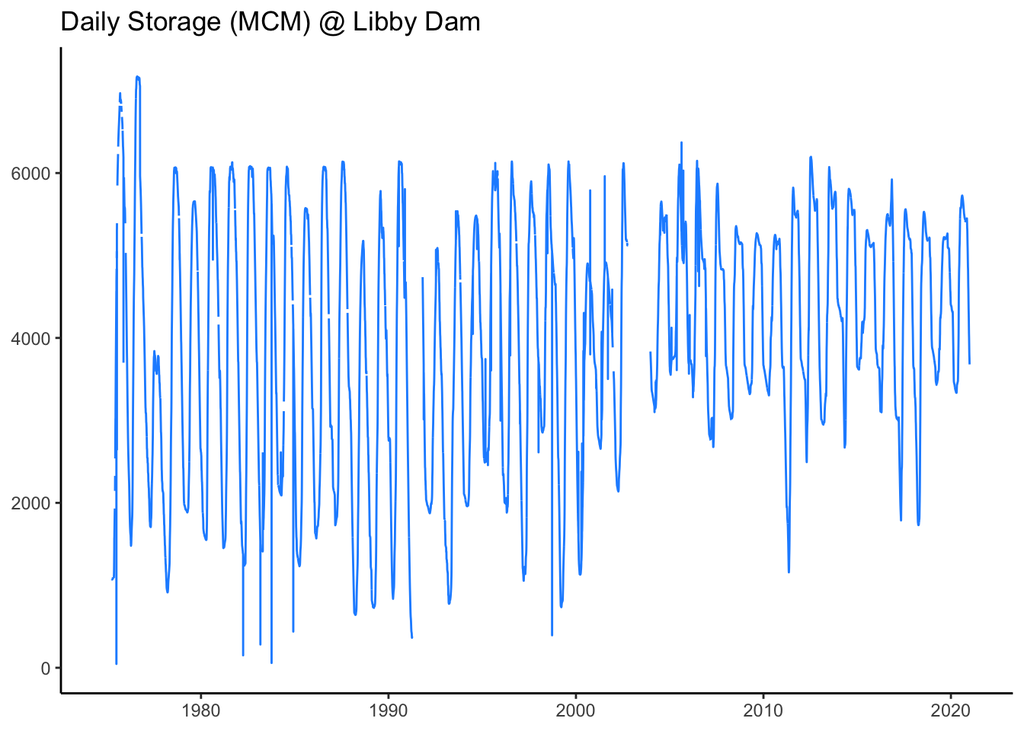

```r
Libby_res_data %>%
  ggplot(aes(date, s_MCM)) + geom_line(col = "dodgerblue") +
  theme_classic() +
  labs(y = NULL, x = NULL, title = "Daily Storage (MCM) @ Libby Dam")
```

To convert these time series data into a normal operating range:

```r
fit_targets(
  "https://raw.githubusercontent.com/IMMM-SFA/starfit/master/inst/extdata/",
  "../../../IM3/Phase 2/P2 WM data-driven/Data-driven reservoir rules/GRanD_Version_1_3/",
  297
) -> Libby_fitted_targets
```

```
## ℹ Fitting targets for dam 297: Libby
```

```r
# NOR parameters are contained in Libby_fitted_targets:
Libby_fitted_targets
```

```
## $id
## [1] 297
##
## $`weekly storage`
## # A tibble: 1,352 × 3
##     year epiweek s_pct
##    <dbl>   <dbl> <dbl>
##  1  1995       1  47.3
##  2  1995       2  43.6
##  3  1995       3  40.8
##  4  1995       4  38.0
##  5  1995       5  35.0
##  6  1995       6  34.1
##  7  1995       7  33.7
##  8  1995       8  33.6
##  9  1995       9  33.8
## 10  1995      10  33.6
## # … with 1,342 more rows
##
## $`NSR upper bound`
## [1]  69.485 -20.769 -10.317  79.371  53.736
##
## $`NSR lower bound`
## [1]  50.647 -38.378  -2.731  63.778  13.631
```

That’s it. If we want to see what those parameters looked like when converted to storage targets:

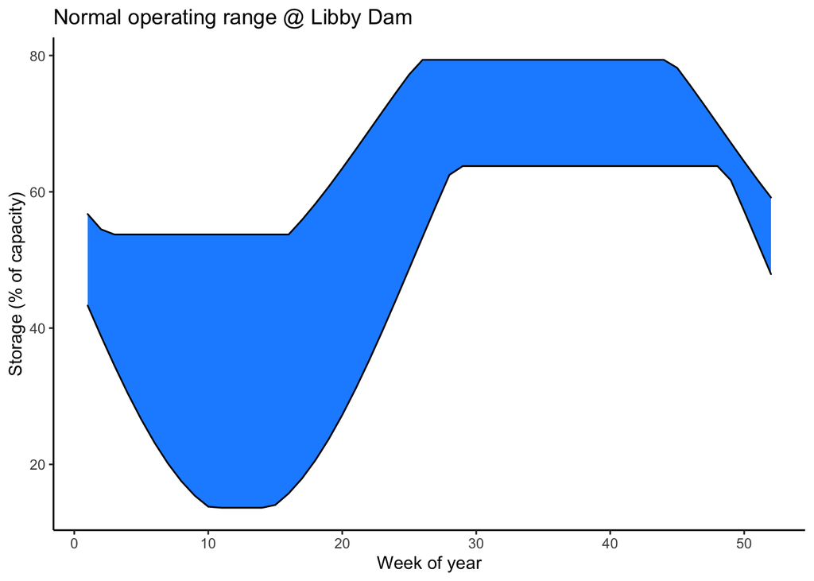

```r
convert_parameters_to_targets(Libby_fitted_targets$`NSR upper bound`, "upper") -> upper_bound
convert_parameters_to_targets(Libby_fitted_targets$`NSR lower bound`, "lower") -> lower_bound

# join and plot
left_join(upper_bound, lower_bound) %>%
  ggplot(aes(epiweek)) + geom_ribbon(aes(ymax = upper, ymin = lower), col = "black", fill = "dodgerblue") +
  labs(title = "Normal operating range @ Libby Dam", x = "Week of year", y = "Storage (% of capacity)") +
  theme_classic()
```